# Computing Residuals

## Computing Residuals

- Classic residuals for continuous random variables (e.g. linear model)

$$r = \text{observed} - \text{expected}$$

- Pearson residuals for GLMs, but shouldn’t really use them…

$$r = \frac{\text{observed} - \text{expected}}{\sqrt{\text{Var}(\text{observed})}}$$

- for Poisson data the variance equals the expected value, which gives the familiar $\sqrt{\text{expected}}$
- Randomized Quantile Residuals
  - considered always an improvement for GLM
  - transform response variable to CDF $F(y|\widehat{\boldsymbol{\theta}})$
  - for discrete random variable draw uniform $[F(y-1|\widehat{\boldsymbol{\theta}}), F(y|\widehat{\boldsymbol{\theta}})]$
  - convert to real line by inverse standard normal
- One Step Ahead Residuals
  - RQR but account for correlation
  - Easy to do in RTMB
  - Becoming common in fisheries

## RTMB Sockeye Ricker

- Consider a model with a temporal random effect

$$\begin{align}
\log(R_i/S_i) & = \alpha_{s_i} + u_t - \beta_{s_i} S_i + \epsilon_i \\
\alpha_{s} & \sim N(\alpha_0, \eta^2) \\
\epsilon_i & \sim N(0, \sigma_{s_i}^2) \\
u_t & \sim N(\phi u_{t-1}, \gamma^2) \\
u_0 & \sim N(0, \gamma^2/(1-\phi^2)) \\
s & \in \{1,\ldots,n_{s}\}\\
t & \in \{1,\ldots, n_{y}\}
\end{align}$$

## Classic Residual Analysis

```r
library(RTMB)

sox$stock <- as.numeric(factor(sox$PopName))
nstocks <- max(sox$stock)
sox <- sox %>% mutate(time = yr - min(yr) + 1)
nyears <- max(sox$time)
minyear <- min(sox$yr)
sox$logRS <- log(sox$recruits/sox$spawners)

## One step ahead residuals (later in this module) predict each observation from
## the ones before it in the data, so put the data in time order first.
sox <- sox %>% arrange(yr, stock)

set.seed(1)   ## random but reproducible starting values, in a plausible range
parameters <- list(
  alpha0 = runif(1, 1, 3),
  re = rnorm(nstocks, 0, 0.1),
  logbeta = runif(nstocks, -1, 0),
  logsigma = runif(nstocks, -0.5, 0.5),
  logsigma_re = log(0.5),
  re_time = rep(0, nyears),
  logitphi = 0,
  logsigma_time = log(0.5)
)

negll <- function(pars){

  getAll(pars, sox, warn = FALSE)
  beta <- exp(logbeta)

  logRS <- OBS(logRS)

  sigma <- exp(logsigma)
  sigma_re <- exp(logsigma_re)
  sigma_time <- exp(logsigma_time)
  sigma_obs <- sigma[stock]
  phi <- 2*plogis(logitphi)-1

  alpha_stock <- re + alpha0
  ADREPORT(alpha_stock)

  mu <- alpha_stock[stock] + re_time[time] - beta[stock]*spawners_scaled

  ## Use this for built in residuals
  ll <- dautoreg(re_time,phi=phi,scale=sqrt(sigma_time^2/(1-phi^2)), log=TRUE)

  ll <- ll + sum(dnorm(re, 0, sigma_re, log = TRUE))
  ll <- ll + sum(dnorm(logRS, mu, sigma_obs, log = TRUE))

  REPORT(mu)
  REPORT(re_time)
  REPORT(sigma_obs)

  return(-ll)
}

obj <- MakeADFun(func = negll, parameters = parameters, random = c("re", "re_time"), silent = TRUE)
fit <- nlminb(obj$par, obj$fn, obj$gr, control = list(eval.max = 1e4, iter.max = 1e4))
fit$message
```

```
[1] "relative convergence (4)"
```

```r
## report at the best parameters found, not the last ones the optimizer tried
rep <- obj$report(obj$env$last.par.best)
sox$expected <- rep$mu
sox$sigma <- rep$sigma_obs
sox <- sox %>%
  mutate(resid = logRS - expected) %>%
  mutate(resid_std = resid/sigma)
```

## Classic Residual Analysis (plot)

- Looks okay
- Conditional on random effects
- Checks if conditional error structure is correct
- Not about random effect structure

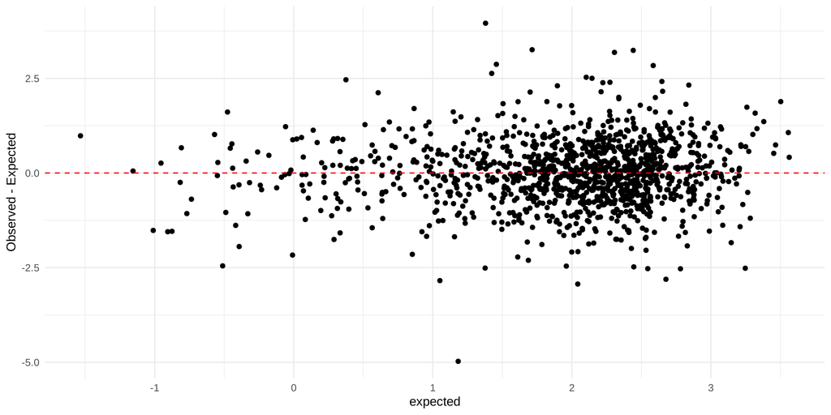

```r
ggplot(data = sox, aes(x = expected, y = resid)) +
  geom_point() + theme_minimal() +
  geom_hline(yintercept = 0, col = 'red', linetype = 2) +
  ylab("Observed - Expected")
```

```r
# qqnorm(sox$resid)
# qqline(sox$resid)
```

## Classic Residual Analysis (group)

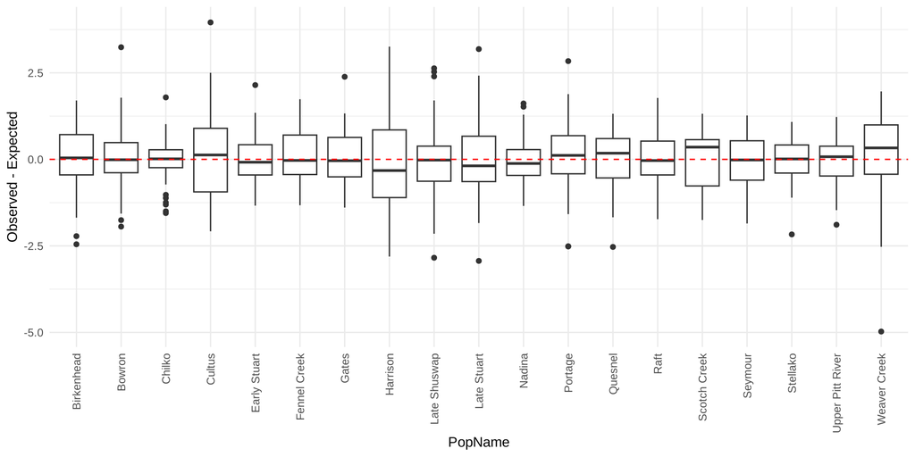

```r
ggplot(data = sox, aes(x = PopName, y = resid)) +
  geom_boxplot() + theme_minimal() +
  geom_hline(yintercept = 0, col = 'red', linetype = 2) +
  ylab("Observed - Expected") +
  theme(axis.text.x = element_text(angle = 90, vjust = 0.5, hjust = 1))
```

## Randomized Quantile Residuals

- Do we know the CDF of this distribution?
- If we don’t know the CDF then we can simulate to approximate it.
- Do we simulate to include the random effect uncertainty (unconditional)?
- In this case, equivalent to standardized residuals

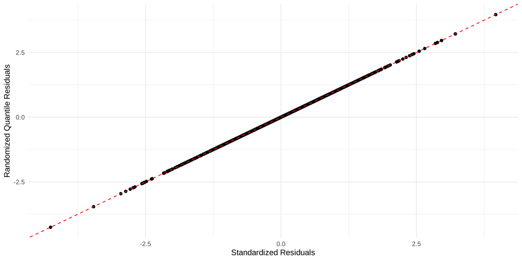

```r
## Known CDF
sox <- sox %>% mutate(cdf = pnorm(logRS, expected, sigma))

## Simulate for CDF
sims <- NULL
for( i in 1:1000 ){
 sims <- cbind(sims, rnorm(nrow(sox), sox$expected, sox$sigma))
}
## What proportion of simulations are less than observed?
## (+0.5 and +1 keep the answer away from exactly 0 or 1, where qnorm() is infinite)
sox$cdf_sim <- sapply(1:nrow(sox), FUN = function(i){(sum(sims[i, ] < sox$logRS[i]) + 0.5)/(1000 + 1)})

## RQR residual
sox$rqr <- qnorm(sox$cdf)
sox$rqr_sim <- qnorm(sox$cdf_sim)

ggplot(data = sox, aes(x = resid_std, y = rqr)) +
  geom_point() + theme_minimal() +
  geom_abline(intercept = 0, slope =1, col = 'red', linetype = 2) +
  xlab("Standardized Residuals") +
  ylab("Randomized Quantile Residuals")
```

## Classic Residual Analysis (time)

- Do the conditional residuals look independent?

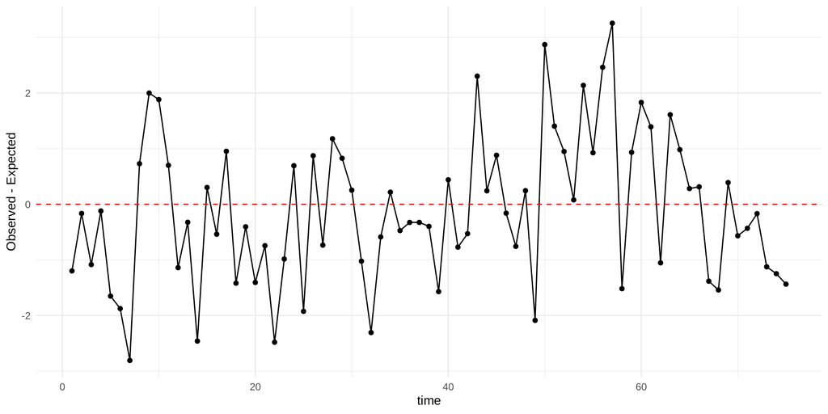

```r
ggplot(data = sox %>% filter(PopName == "Harrison"), aes(x = time, y = resid,)) +
  geom_point() + geom_line() + theme_minimal() +
  geom_hline(yintercept = 0, col = 'red', linetype = 2) +
  ylab("Observed - Expected")
```

## One Step Ahead Residuals

- We have assumed that the residuals are independent.
- If they aren’t, then you can get bad looking residuals even if the model is ‘correct’
- Instead, we can condition each residual on all the observations before it

$$(y_i - \widehat{y}_{i|1,\ldots,i-1})/\widehat{\sigma}_{i|1,\ldots,i-1}$$
- “Before” means earlier in the data vector. That is why we sorted the data by year: each observation is predicted from earlier years (and from the stocks already seen in its own year).

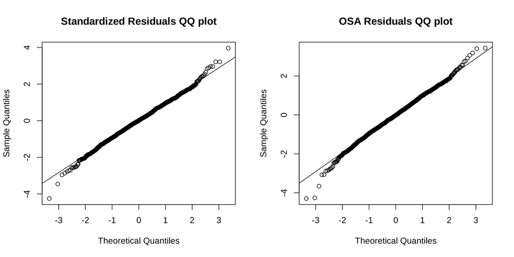

```r
## Data and random effects are all normal here, so "fullGaussian" is exact (and fast).
resid_osa <- oneStepPredict(obj, method = "fullGaussian", trace = FALSE)
sox$resid_osa <- resid_osa$residual

par(mfrow = c(1,2))
qqnorm(sox$resid_std, main = "Standardized Residuals QQ plot")
qqline(sox$resid_std)

qqnorm(resid_osa$residual, main = "OSA Residuals QQ plot")
qqline(resid_osa$residual)
```

## Which Method?

- `oneStepPredict()` has several methods. Use the first in this list that fits your model:
  - `"fullGaussian"`: data and random effects all normal. Exact, and takes 3 seconds here.
  - `"oneStepGaussian"`: normal data, any random effects.
  - `"cdf"`: every data density has a CDF (`pnorm`, `ppois`, …). Good for counts.
  - `"oneStepGeneric"`: anything else. Takes minutes here, and is less accurate.
- Mark the data with `OBS()`. For counts add `discrete = TRUE` and set a seed.
- The order of the data matters: sorted differently, you get different (still valid) residuals.

## Are the Residuals Independent in Time?

- A QQ plot checks the shape of the distribution, not independence.
- Compare each residual with the one from the same stock a year earlier.

```r
lag1 <- sox %>% group_by(PopName) %>% arrange(yr, .by_group = TRUE) %>%
  mutate(resid_prev = ifelse(yr - lag(yr) == 1, lag(resid_osa), NA)) %>%
  ungroup() %>% filter(!is.na(resid_prev))

## All stocks together: correlation and its 95% confidence interval
ct <- cor.test(lag1$resid_osa, lag1$resid_prev)
round(c(correlation = unname(ct$estimate), lower = ct$conf.int[1], upper = ct$conf.int[2]), 2)
```

```
correlation       lower       upper
       0.16        0.11        0.22
```

```r
## The five stocks with the most left over
lag1 %>% group_by(PopName) %>% summarize(lag1_cor = round(cor(resid_osa, resid_prev), 2)) %>%
  arrange(desc(lag1_cor)) %>% head(5)
```

```
# A tibble: 5 × 2
  PopName          lag1_cor
  <chr>               <dbl>
1 Cultus               0.49
2 Raft                 0.32
3 Upper Pitt River     0.32
4 Scotch Creek         0.3
5 Birkenhead           0.28
```

- A shared year effect cannot follow a run of good or bad years in one stock. Try a year effect for each stock (Module 5 practical), or the latent variable example.

## Checking the Random Effects

- Residuals for the data do not check the model for the random effects.
- The estimated random effects are no use for this: they are shrunk towards zero, so they look better behaved than they are.
- Instead take **one draw** of the random effects from their distribution given the data (Waagepetersen 2006; Thygesen et al. 2017).
- Check that draw against what the model says. Look for outlying years, runs of the same sign, and trends.

## One Draw of the Random Effects

```r
sdr <- sdreport(obj, getJointPrecision = TRUE)
ir <- obj$env$random                         ## where the random effects are in the parameter vector
Q <- as.matrix(sdr$jointPrecision[ir, ir])   ## their precision (inverse covariance)

## One draw: mode + R^-1 z has covariance Q^-1 when Q = R'R.
## Try other seeds: a real problem shows up in almost every draw.
set.seed(11)
u <- obj$env$last.par.best[ir] + backsolve(chol(Q), rnorm(length(ir)))
u_time <- u[names(u) == "re_time"]

## If the AR(1) model is right, these are independent standard normals
phi <- 2*plogis(fit$par[["logitphi"]]) - 1
sigma_time <- exp(fit$par[["logsigma_time"]])
innov <- c(u_time[1]*sqrt(1 - phi^2), u_time[-1] - phi*u_time[-nyears])/sigma_time
round(c(sd = sd(innov), lag1_cor = acf(innov, plot = FALSE)$acf[2], shapiro_p = shapiro.test(innov)$p.value), 3)
```

```
       sd  lag1_cor shapiro_p
    0.991    -0.180     0.001
```

## One Draw of the Random Effects (plot)

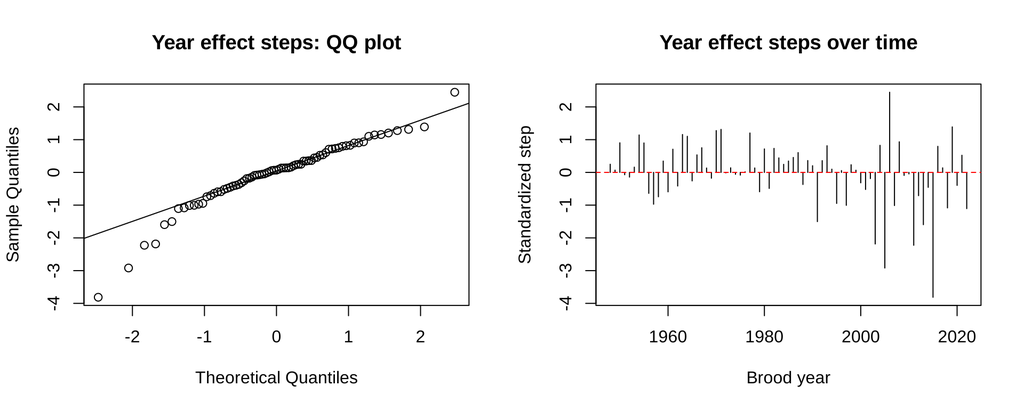

```r
par(mfrow = c(1,2))
qqnorm(innov, main = "Year effect steps: QQ plot")
qqline(innov)
plot(minyear + 1:nyears - 1, innov, type = "h", xlab = "Brood year", ylab = "Standardized step",
     main = "Year effect steps over time")
abline(h = 0, col = "red", lty = 2)
```

## End of Module

- See *osa_multinomial.qmd* example for a multinomial distribution
- A residual check has three parts: the shape of the distribution, independence (in time and by group), and the random effects
- As our model becomes more complicated, we need to think harder about the residual analysis
- If you have non-normal data, always use RQR residuals, or OSA
- The more we want to code ‘custom’ the more work we need to also do for model checking, validation, and reporting